# Final Project EDA

Junhua Tan

5/11/2020

## Initial Overview

### Win Rates

```
## # A tibble: 2 x 3
##   blue_wins     n  prop
##   <fct>     <int> <dbl>
## 1 0           893 0.502
## 2 1           885 0.498
```

- There are about the same amount of data that the blue team wins and losses.

### Variables

Data summary

| Name | Piped data |
| --- | --- |
| Number of rows | 1778 |
| Number of columns | 15 |
| _______________________ |  |
| Column type frequency: |  |
| factor | 4 |
| numeric | 11 |
| ________________________ |  |
| Group variables | None |

**Variable type: factor**

| skim_variable | n_missing | complete_rate | ordered | n_unique | top_counts |
| --- | --- | --- | --- | --- | --- |
| blue_wins | 0 | 1 | FALSE | 2 | 0: 893, 1: 885 |
| first_blood | 0 | 1 | FALSE | 2 | 0: 909, 1: 869 |
| dragons | 0 | 1 | FALSE | 3 | -1: 717, 1: 655, 0: 406 |
| heralds | 0 | 1 | FALSE | 3 | 0: 1144, 1: 359, -1: 275 |

**Variable type: numeric**

| skim_variable | n_missing | complete_rate | mean | sd | p0 | p25 | p50 | p75 | p100 |
| --- | --- | --- | --- | --- | --- | --- | --- | --- | --- |
| experience | 0 | 1 | -85.64 | 1963.60 | -6118.0 | -1342.50 | -70.00 | 1171.00 | 7609.0 |
| kills | 0 | 1 | -0.19 | 4.23 | -15.0 | -3.00 | 0.00 | 3.00 | 16.0 |
| assists | 0 | 1 | -0.34 | 5.76 | -21.0 | -4.00 | 0.00 | 3.00 | 17.0 |
| towers_destroyed | 0 | 1 | 0.00 | 0.31 | -2.0 | 0.00 | 0.00 | 0.00 | 3.0 |
| wards_placed | 0 | 1 | 0.09 | 25.27 | -197.0 | -4.00 | 0.00 | 4.00 | 234.0 |
| wards_destroyed | 0 | 1 | -0.02 | 2.81 | -20.0 | -1.00 | 0.00 | 1.00 | 18.0 |
| cs_per_min | 0 | 1 | -0.09 | 3.06 | -11.1 | -2.10 | -0.10 | 2.00 | 12.7 |
| gold_per_min | 0 | 1 | -10.04 | 248.16 | -795.2 | -173.47 | -10.35 | 146.47 | 865.7 |
| avg_level | 0 | 1 | -0.02 | 0.49 | -1.8 | -0.40 | 0.00 | 0.40 | 2.4 |
| elite_monsters | 0 | 1 | 0.01 | 1.07 | -2.0 | -1.00 | 0.00 | 1.00 | 2.0 |
| total_jungle_minions_killed | 0 | 1 | -0.03 | 13.87 | -50.0 | -9.00 | 0.00 | 9.00 | 41.0 |

- There are total of 1778 observations in the EDA dataset splited from the original source from Kaggle. [data source: League of Legends Diamond Ranked Games (10 min), Version 1. Retrieved April 24, 2020 from https://www.kaggle.com/bobbyscience/league-of-legends-diamond-ranked-games-10-min]
- There are total of 14 predictors to the response variable `blue_wins`.
- There are no missing values in any of the variables.

## Essential Findings

### Wins and First Blood

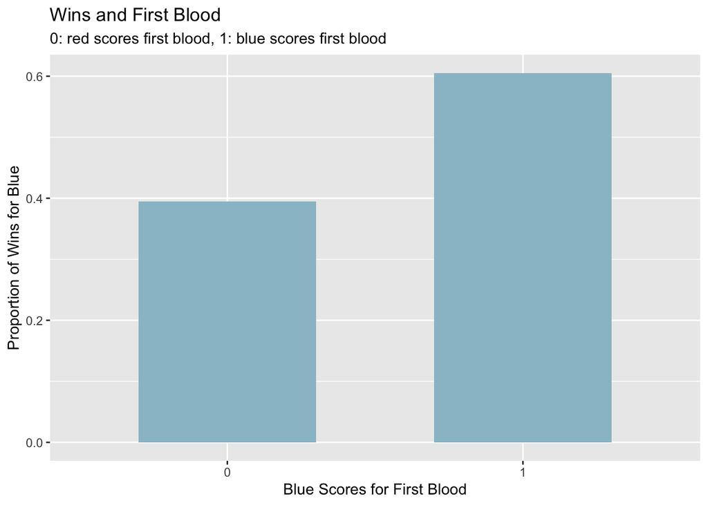

- First blood is the first kill in the game, rewarded by additional gold and experience than other kills.
- There is a positive relationship between scoring first blood in the game and winning, as shown by the higher proportion of wins for the blue side when it scores for first blood (`first_blood == 1`).

### Wins and Dragons

```
## # A tibble: 3 x 3
##   dragons total  prop
##   <fct>   <int> <dbl>
## 1 1         655 0.368
## 2 0         406 0.228
## 3 -1        717 0.403
```

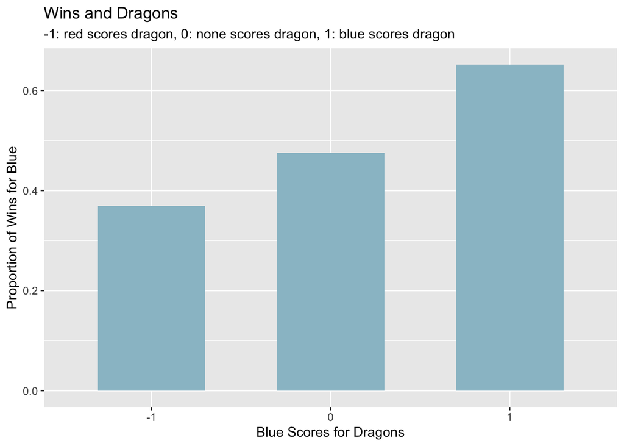

- Dragon is an elite monster which gives team bonus when killed.
- When the opposite (red) side scores the dragon, proportion of wins is less than 0.5 and vice versa.
- When both teams did not scores the dragon in the first 10 minutes (which accounts for 22.8% of the EDA dataset), the proportion of wins for blue is around 0.5, that is, both sides have the same proportion of wins.
- Overall, there is a positive relationship between scoring a dragon and winning such that the side which scores a dragon tend to have a higher proportion of wins.

### Wins and Wards Placed

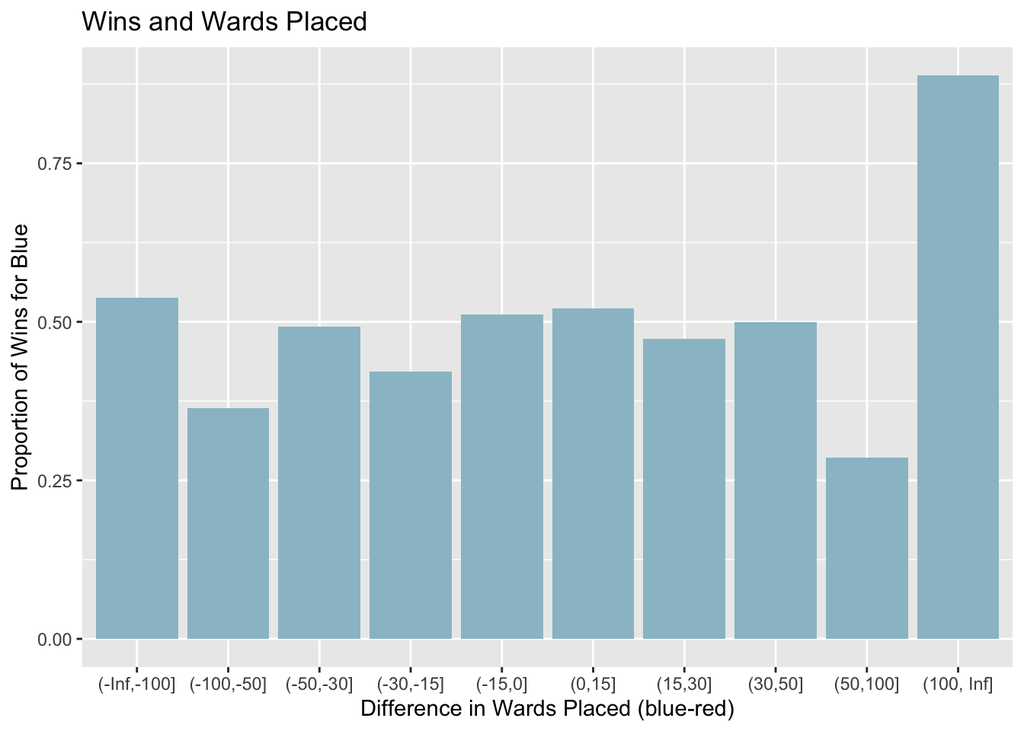

### Wins and Wards Destoryed

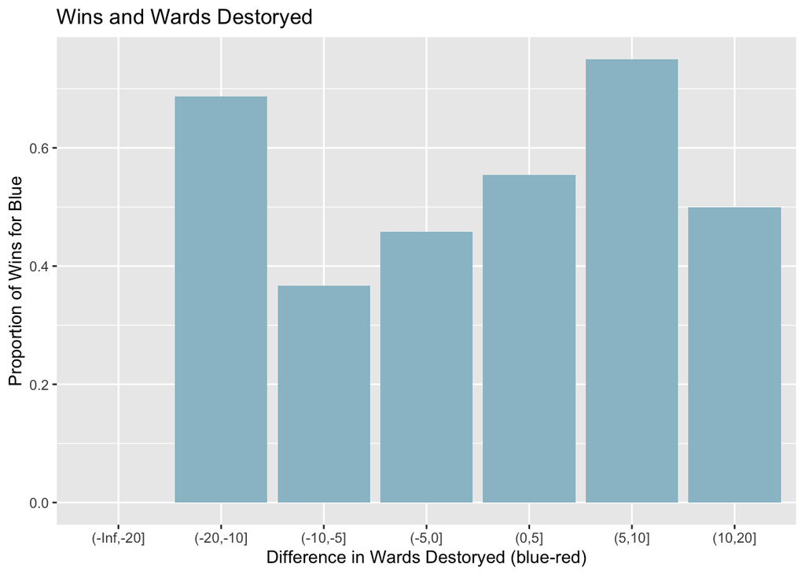

## Secondary Findings

### Wins and Kills

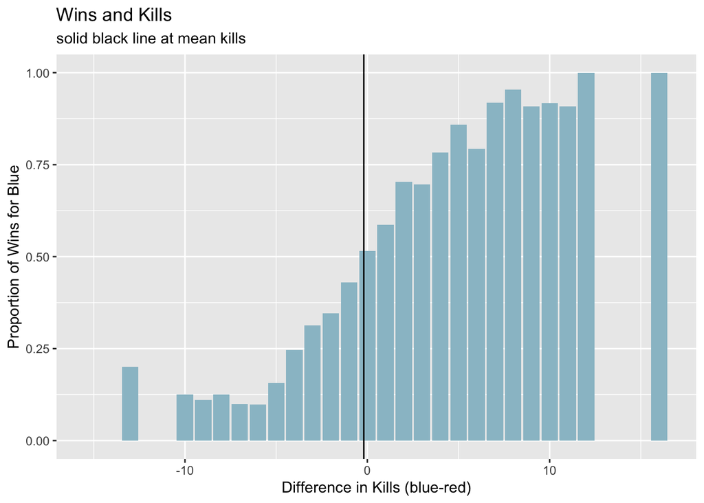

- As expected, when there is a disadvantage in kills for the blue side, the proportion of wins for blue is less and vice versa.
- When there is no difference in kills (~0), the proportion of wins for blue is around 0.5, that is, both sides have the same proportion of wins.
- Overall, there is a positive relationship between numbers of kills and winning such that scoring more kills than the other side tends to have a higher proportion of wins.

### Wins and Experience

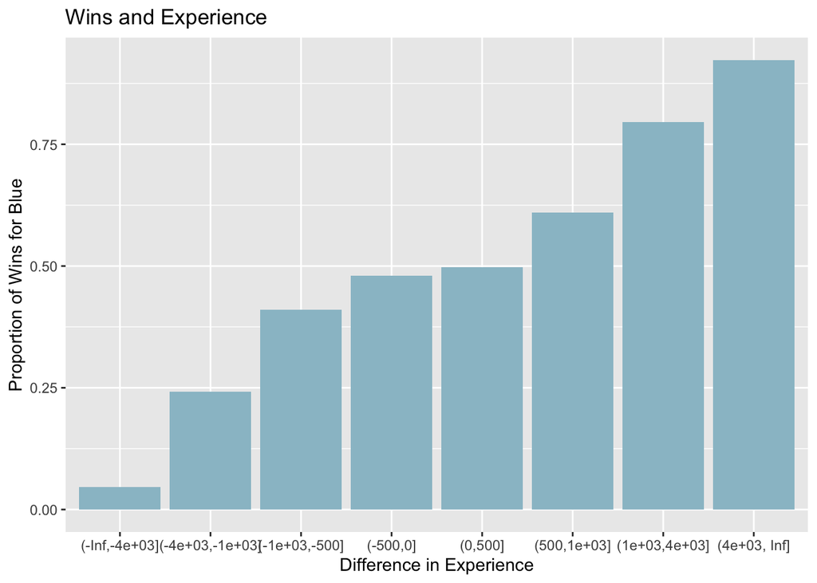

- Experience is the requirement for level up in games, it can be gained from killing minions, enemies, elite monsters (dragon or herald) as well as destorying towers.
- The difference in total experience of the teams have a positive relationship with proportion of winning such that as this difference increases (i.e. blue team has more experience than the red team), the proportion of blue winning also increases.
- A small difference in experience (-500, 500] does not show an obvious effect in winning such that the proportion of wins is around 0.5 from the bar chart. Only those above the threshold of 500 shows effective for predicting wins.

### Wins and Gold Per Minutes

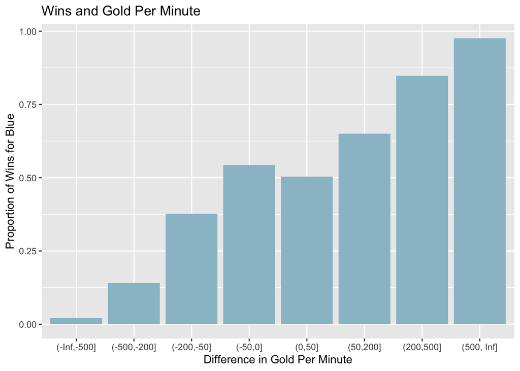

### Wins and Tower Destoryed

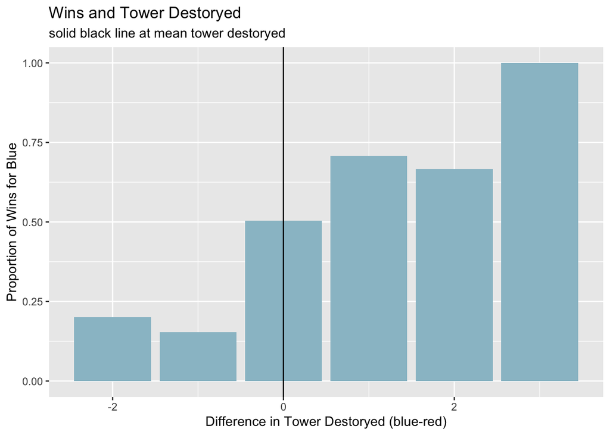

- Tower is a structure you have to destroy to reach the enemy Nexus (goal of the game). Destruction of tower will give gold and experience.
- As expected, when the opposite (red) side takes down more towers (closer to the goal of the Nexus), proportion of wins is significantly less than 0.5 and vice versa.
- When both teams takes down the same amount of towers in the first 10 minutes, which is also the average tower takedown difference, the proportion of wins for blue is around 0.5 and both sides have the same proportion of wins.
- Overall, there is a positive relationship between numbers of tower destoryed and winning such that the side with more tower destoryed tends to have a higher proportion of wins.